# Boletín Tema 1

Tratamiento de Datos. Grado en Ciencia de Datos- UV

Carlos Gila Blanco

2022-02-16

1. Considera los conjuntos de datos **mammals** del paquete **MASS** y **Animals2** del paquete **robustbase**.
1. Mira la las características de ambos conjuntos usando la ayuda.
2. Usa las funciones **dim, head, tail, str** para una primera visión de los conjuntos de datos.
3. Muestra los nombres de las filas y las columnas (**rownames**, **colnames**)

```r
data("mammals")
data("Animals2")

dim(mammals)
```

```
[1] 62  2
```

```r
dim(Animals2)
```

```
[1] 65  2
```

```r
head(mammals)
```

|  | body | brain |
| --- | --- | --- |
| Arctic fox | 3.385 | 44.5 |
| Owl monkey | 0.480 | 15.5 |
| Mountain beaver | 1.350 | 8.1 |
| Cow | 465.000 | 423.0 |
| Grey wolf | 36.330 | 119.5 |
| Goat | 27.660 | 115.0 |

```r
head(Animals2)
```

|  | body | brain |
| --- | --- | --- |
| Mountain beaver | 1.35 | 8.1 |
| Cow | 465.00 | 423.0 |
| Grey wolf | 36.33 | 119.5 |
| Goat | 27.66 | 115.0 |
| Guinea pig | 1.04 | 5.5 |
| Dipliodocus | 11700.00 | 50.0 |

```r
tail(mammals)
```

|  | body | brain |
| --- | --- | --- |
| Echidna | 3.000 | 25.0 |
| Brazilian tapir | 160.000 | 169.0 |
| Tenrec | 0.900 | 2.6 |
| Phalanger | 1.620 | 11.4 |
| Tree shrew | 0.104 | 2.5 |
| Red fox | 4.235 | 50.4 |

```r
tail(Animals2)
```

|  | body | brain |
| --- | --- | --- |
| Echidna | 3.000 | 25.0 |
| Brazilian tapir | 160.000 | 169.0 |
| Tenrec | 0.900 | 2.6 |
| Phalanger | 1.620 | 11.4 |
| Tree shrew | 0.104 | 2.5 |
| Red fox | 4.235 | 50.4 |

```r
str(mammals)
```

```
'data.frame':   62 obs. of  2 variables:
 $ body : num  3.38 0.48 1.35 465 36.33 ...
 $ brain: num  44.5 15.5 8.1 423 119.5 ...
```

```r
str(Animals2)
```

```
'data.frame':   65 obs. of  2 variables:
 $ body : num  1.35 465 36.33 27.66 1.04 ...
 $ brain: num  8.1 423 119.5 115 5.5 ...
```

```r
rownames(mammals)
```

```
 [1] "Arctic fox"                "Owl monkey"
 [3] "Mountain beaver"           "Cow"
 [5] "Grey wolf"                 "Goat"
 [7] "Roe deer"                  "Guinea pig"
 [9] "Verbet"                    "Chinchilla"
[11] "Ground squirrel"           "Arctic ground squirrel"
[13] "African giant pouched rat" "Lesser short-tailed shrew"
[15] "Star-nosed mole"           "Nine-banded armadillo"
[17] "Tree hyrax"                "N.A. opossum"
[19] "Asian elephant"            "Big brown bat"
[21] "Donkey"                    "Horse"
[23] "European hedgehog"         "Patas monkey"
[25] "Cat"                       "Galago"
[27] "Genet"                     "Giraffe"
[29] "Gorilla"                   "Grey seal"
```

[output cut: 16 more lines]

```r
rownames(Animals2)
```

```
 [1] "Mountain beaver"           "Cow"
 [3] "Grey wolf"                 "Goat"
 [5] "Guinea pig"                "Dipliodocus"
 [7] "Asian elephant"            "Donkey"
 [9] "Horse"                     "Potar monkey"
[11] "Cat"                       "Giraffe"
[13] "Gorilla"                   "Human"
[15] "African elephant"          "Triceratops"
[17] "Rhesus monkey"             "Kangaroo"
[19] "Golden hamster"            "Mouse"
[21] "Rabbit"                    "Sheep"
[23] "Jaguar"                    "Chimpanzee"
[25] "Rat"                       "Brachiosaurus"
[27] "Mole"                      "Pig"
[29] "Artic fox"                 "Owl monkey"
```

[output cut: 18 more lines]

```r
colnames(mammals)
```

```
[1] "body"  "brain"
```

```r
colnames(Animals2)
```

```
[1] "body"  "brain"
```

4. Usa la función **intersect** y almacena en la variable *commonAnimals* los aminales que aparezcan en ambos conjuntos

```r
commonAnimals <- intersect(Animals2, mammals)
```

5. Usa **setdiff** para averiguar qué animales no están en ambos conjuntos. ¿Cuántos son ?. ¿Qué tipo de animales son?

```r
notinboth <- setdiff(Animals2, mammals)
#Los 3 animales que no están son el diplodocus, el triceratops y el braquiosaurio, que son dinosaurios, y por tanto, no pueden estar en "mammals".
```

5. Determina las diferencia entre los animales que no aparecen en ambos conjuntos.

```r
#Está hecho arriba y guardado en "notinboth
```

2. La funcion **qqPlot** del paquete **car** puede ser utilizada para determinar gráficamente si una serie de puntos siguen una distribución de datos Gaussiana. Si las muestras están dentro de las líneas discontinuas podemos indicar que siguen una distribución Gaussiana con un 95 % de confianza. Utilizando esta función representa el logaritmo neperiano (**log**) del peso del cerebro (**brain weigths**) del registro de datos **mammals** del paquete **MASS** y conjunto de datos **Animals2** de la librería **robustbase**. ¿Presentan el mismo comportamiento ?.¿Podríamos decir que siguen una distribución Gaussiana ?

```
[1] 33 19
```

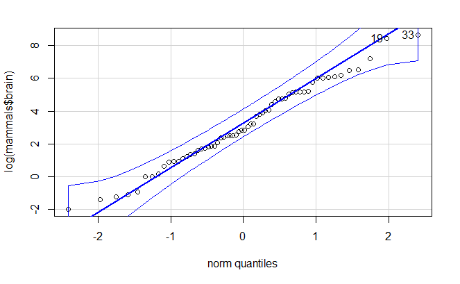

```r
qqPlot(log(mammals$brain))
```

```
Error in gzfile(file, "wb") : cannot open the connection
```

```
[1] 15  7
```

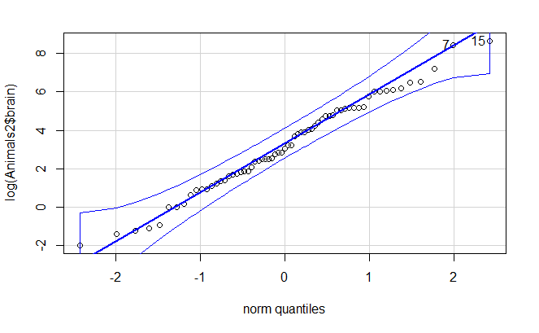

```r
qqPlot(log(Animals2$brain))
```

```r
#Su representación es ligeramente distinta debido a la aparición de 3 animales más en "Animals2", pero en ambos casos se puede concluir que se sigue una distribución Gaussiana.
```

```
Error in gzfile(file, "wb") : cannot open the connection
```

3. La función **library** sin argumentos abre una ventana y muestra las librerías que han sido instaladas.
   1. Asigna el valor devuelto por esta función a la variable **libReturn** y observa su estructura.
   2. Uno de los elementos de la lista es un matriz de caracteres. Muestra por pantalla los 5 primeros elementos de esta matriz usando la función **head**.
   3. Determina el número de librerías que tienes instaladas.

[output not shown]

[output not shown]

[output not shown]

[output not shown]

4. En las transparencias del tema 1 se citan los primeros pasos a seguir cuando se analiza un nuevo conjunto de datos.
   1. Determina las tres primeras etapas para el conjunto de datos **cabbages** del paquete **MASS**
   2. Puedes determinar el número de valores perdidos (almacenados como **NA** en R) usando la función **is.na**. Determina el número de valores perdidos para cada una de las variables del conjunto **cabbages**.
   3. Repite los apartados anteriores con el conjunto de datos **Chile** del paquete **car**.
   4. Utiliza la función **summary**, sobre **cabbages** y **Chile** y observa como, además de otros estadísticos, también devuelve el número de valores perdidos de cada variable.

```r
#1. Importación
data("cabbages")

str(cabbages)
```

```
'data.frame':   60 obs. of  4 variables:
 $ Cult  : Factor w/ 2 levels "c39","c52": 1 1 1 1 1 1 1 1 1 1 ...
 $ Date  : Factor w/ 3 levels "d16","d20","d21": 1 1 1 1 1 1 1 1 1 1 ...
 $ HeadWt: num  2.5 2.2 3.1 4.3 2.5 4.3 3.8 4.3 1.7 3.1 ...
 $ VitC  : int  51 55 45 42 53 50 50 52 56 49 ...
```

```r
head(cabbages)
```

|  | Cult | Date | HeadWt | VitC |
| --- | --- | --- | --- | --- |
| 1 | c39 | d16 | 2.5 | 51 |
| 2 | c39 | d16 | 2.2 | 55 |
| 3 | c39 | d16 | 3.1 | 45 |
| 4 | c39 | d16 | 4.3 | 42 |
| 5 | c39 | d16 | 2.5 | 53 |
| 6 | c39 | d16 | 4.3 | 50 |

```r
tail(cabbages)
```

|  | Cult | Date | HeadWt | VitC |
| --- | --- | --- | --- | --- |
| 55 | c52 | d21 | 1.7 | 71 |
| 56 | c52 | d21 | 1.6 | 72 |
| 57 | c52 | d21 | 1.4 | 62 |
| 58 | c52 | d21 | 1.0 | 68 |
| 59 | c52 | d21 | 1.5 | 66 |
| 60 | c52 | d21 | 1.6 | 72 |

```r
dim(cabbages)
```

```
[1] 60  4
```

```r
is.na(cabbages)
```

```
    Cult  Date HeadWt  VitC
1  FALSE FALSE  FALSE FALSE
2  FALSE FALSE  FALSE FALSE
3  FALSE FALSE  FALSE FALSE
4  FALSE FALSE  FALSE FALSE
5  FALSE FALSE  FALSE FALSE
6  FALSE FALSE  FALSE FALSE
7  FALSE FALSE  FALSE FALSE
8  FALSE FALSE  FALSE FALSE
9  FALSE FALSE  FALSE FALSE
10 FALSE FALSE  FALSE FALSE
11 FALSE FALSE  FALSE FALSE
12 FALSE FALSE  FALSE FALSE
13 FALSE FALSE  FALSE FALSE
14 FALSE FALSE  FALSE FALSE
```

[output cut: 46 more lines]

```r
lapply(cabbages, function(x){if (is.na(x)){
  rm(x)
}})
```

[output not shown]

```r
data("Chile")

str(Chile)
```

```
'data.frame':   2700 obs. of  8 variables:
 $ region    : Factor w/ 5 levels "C","M","N","S",..: 3 3 3 3 3 3 3 3 3 3 ...
 $ population: int  175000 175000 175000 175000 175000 175000 175000 175000 175000 175000 ...
 $ sex       : Factor w/ 2 levels "F","M": 2 2 1 1 1 1 2 1 1 2 ...
 $ age       : int  65 29 38 49 23 28 26 24 41 41 ...
 $ education : Factor w/ 3 levels "P","PS","S": 1 2 1 1 3 1 2 3 1 1 ...
 $ income    : int  35000 7500 15000 35000 35000 7500 35000 15000 15000 15000 ...
 $ statusquo : num  1.01 -1.3 1.23 -1.03 -1.1 ...
 $ vote      : Factor w/ 4 levels "A","N","U","Y": 4 2 4 2 2 2 2 2 3 2 ...
```

```r
head(Chile)
```

|  | region | population | sex | age | education | income | statusquo | vote |
| --- | --- | --- | --- | --- | --- | --- | --- | --- |
| 1 | N | 175000 | M | 65 | P | 35000 | 1.00820 | Y |
| 2 | N | 175000 | M | 29 | PS | 7500 | -1.29617 | N |
| 3 | N | 175000 | F | 38 | P | 15000 | 1.23072 | Y |
| 4 | N | 175000 | F | 49 | P | 35000 | -1.03163 | N |
| 5 | N | 175000 | F | 23 | S | 35000 | -1.10496 | N |
| 6 | N | 175000 | F | 28 | P | 7500 | -1.04685 | N |

```r
tail(Chile)
```

|  | region | population | sex | age | education | income | statusquo | vote |
| --- | --- | --- | --- | --- | --- | --- | --- | --- |
| 2695 | M | 15000 | M | 42 | S | 35000 | -0.00233 | U |
| 2696 | M | 15000 | M | 42 | P | 15000 | -1.26247 | N |
| 2697 | M | 15000 | F | 28 | P | 15000 | 1.32950 | Y |
| 2698 | M | 15000 | F | 44 | P | 75000 | 1.42045 | Y |
| 2699 | M | 15000 | M | 21 | S | 75000 | 0.18315 | NA |
| 2700 | M | 15000 | M | 20 | PS | 35000 | 1.38179 | Y |

```r
dim(Chile)
```

```
[1] 2700    8
```

```r
is.na(Chile)
```

```
     region population   sex   age education income statusquo  vote
1     FALSE      FALSE FALSE FALSE     FALSE  FALSE     FALSE FALSE
2     FALSE      FALSE FALSE FALSE     FALSE  FALSE     FALSE FALSE
3     FALSE      FALSE FALSE FALSE     FALSE  FALSE     FALSE FALSE
4     FALSE      FALSE FALSE FALSE     FALSE  FALSE     FALSE FALSE
5     FALSE      FALSE FALSE FALSE     FALSE  FALSE     FALSE FALSE
6     FALSE      FALSE FALSE FALSE     FALSE  FALSE     FALSE FALSE
7     FALSE      FALSE FALSE FALSE     FALSE  FALSE     FALSE FALSE
8     FALSE      FALSE FALSE FALSE     FALSE  FALSE     FALSE FALSE
9     FALSE      FALSE FALSE FALSE     FALSE  FALSE     FALSE FALSE
10    FALSE      FALSE FALSE FALSE     FALSE  FALSE     FALSE FALSE
11    FALSE      FALSE FALSE FALSE     FALSE  FALSE     FALSE FALSE
12    FALSE      FALSE FALSE FALSE     FALSE  FALSE     FALSE FALSE
13    FALSE      FALSE FALSE FALSE     FALSE   TRUE     FALSE FALSE
14    FALSE      FALSE FALSE FALSE     FALSE  FALSE     FALSE FALSE
```

[output cut: 112 more lines]

```r
colSums(sapply(Chile, is.na))
```

```
    region population        sex        age  education     income  statusquo
         0          0          0          1         11         98         17
      vote
       168
```

```r
summary(cabbages)
```

```
  Cult     Date        HeadWt           VitC
 c39:30   d16:20   Min.   :1.000   Min.   :41.00
 c52:30   d20:20   1st Qu.:1.875   1st Qu.:50.75
          d21:20   Median :2.550   Median :56.00
                   Mean   :2.593   Mean   :57.95
                   3rd Qu.:3.125   3rd Qu.:66.25
                   Max.   :4.300   Max.   :84.00
```

```r
summary(Chile)
```

```
 region     population     sex           age        education
 C :600   Min.   :  3750   F:1379   Min.   :18.00   P   :1107
 M :100   1st Qu.: 25000   M:1321   1st Qu.:26.00   PS  : 462
 N :322   Median :175000            Median :36.00   S   :1120
 S :718   Mean   :152222            Mean   :38.55   NA's:  11
 SA:960   3rd Qu.:250000            3rd Qu.:49.00
          Max.   :250000            Max.   :70.00
                                    NA's   :1
     income         statusquo          vote
 Min.   :  2500   Min.   :-1.80301   A   :187
 1st Qu.:  7500   1st Qu.:-1.00223   N   :889
 Median : 15000   Median :-0.04558   U   :588
 Mean   : 33876   Mean   : 0.00000   Y   :868
 3rd Qu.: 35000   3rd Qu.: 0.96857   NA's:168
 Max.   :200000   Max.   : 2.04859
 NA's   :98       NA's   :17
```

5. Muchas pruebas estadísticas suponen que los datos siguen una distribución Gaussiana. Utiliza la aproximación visual proporcionada por **qqPlot** para determinar si podemos asumir que las variables **HeadWt** y **VitC** del conjunto **cabbages** verifican esta condición.

```
[1] 4 6
```

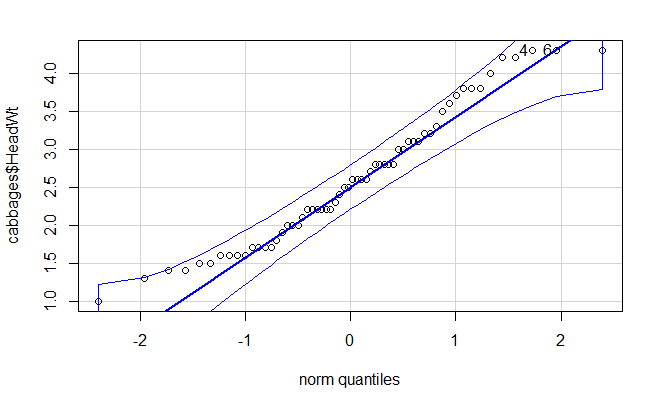

```r
qqPlot(cabbages$HeadWt)
```

```
Error in gzfile(file, "wb") : cannot open the connection
```

```
[1] 54 51
```

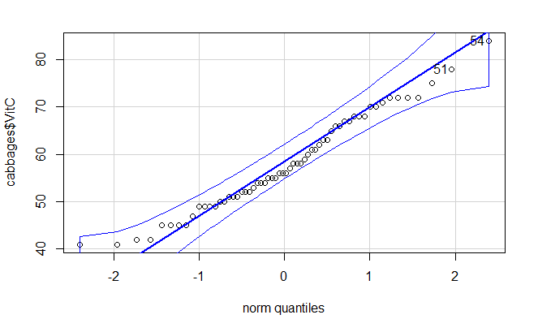

```r
qqPlot(cabbages$VitC)
```

```r
#Como los puntos del plot están dentro de las líneas discontinuas en ambos casos, podemos afirmar que se trata de dos distribuciones Gaussianas.
```

```
Error in gzfile(file, "wb") : cannot open the connection
```

6. Una representación habitual, para determinar la distribución de los datos de una variable cuantitativa es el histograma (**hist**). Determina, de forma aproximada, utilizando el histograma, si hay diferencias entre los contenidos de vitamina C (**VitC**), para las diferentes variedades de calabaza (variable **Cult**), en el conjunto de datos **cabbages**.

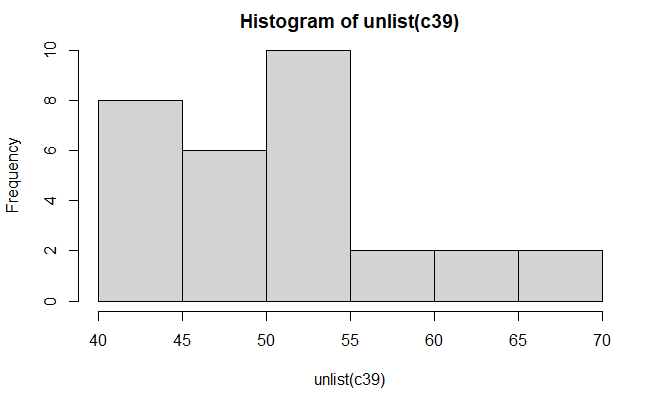

```r
c39 <- list()
c52 <- list()

for(i in 1:nrow(cabbages)){
  if(cabbages$Cult[i] == "c39"){
    c39[[i]] <- cabbages$VitC[i]
  }else{
    c52[[i]] <- cabbages$VitC[i]
  }
}

c52 <- c52[-which(sapply(c52, is.null))]

hist(unlist(c39))
```

```
Error in gzfile(file, "wb") : cannot open the connection
```

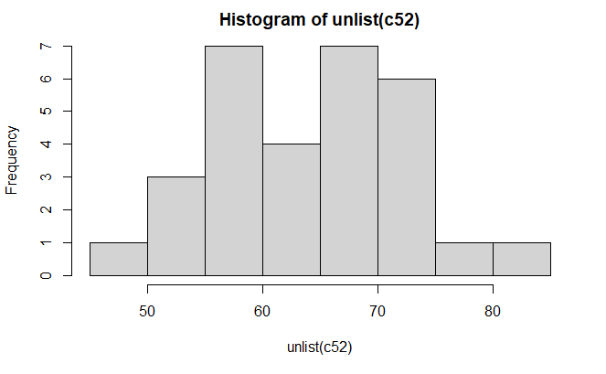

```r
hist(unlist(c52))
```

```r
#La variedad c52 contiene una cantidad ligeramente más elevada que la c39
```

```
Error in gzfile(file, "wb") : cannot open the connection
```

7. Un modelo sencillo para relacionar variables es la *predicción lineal*. En el siguiente ejemplo se utiliza el conjunto de datos **whiteside**, de la librería **MASS**. Esta aproximación propone un modelo que predice una variable a partir de otra. Una primera etapa para plantear esta aproximación sería representar ambas variables mediante un diagrama de dispersión (Gráfico XY) y determinar si la relación entre variables “parece” lineal. Si es así, podemos plantear un modelo lineal (en este caso según un factor), donde se aprecia claramente que existe una relación lineal entre las dos variables consideradas. Observa y ejecuta el siguiente código.

```r
#Diagrama de dispersión global.
plot(whiteside$Temp, whiteside$Gas)
#Diagrama de dispersión etiquetando según un factor.
plot(whiteside$Temp, whiteside$Gas, pch=c(6,16)[whiteside$Insul])
legend(x="topright",legend=c("Insul = Before","Insul = After"), pch=c(6,16))
# Planteamos 2 modelos lineales, uno para los datos de cada factor
Model1 <- lm(Gas ~ Temp, data = whiteside, subset = which(Insul == "Before"))
Model2 <- lm(Gas ~ Temp, data = whiteside, subset = which(Insul == "After"))
# Representamos las rectas correspondientes a cada modelo lineal
abline(Model1, lty=2)
abline(Model2)
```

[output not shown]

1. Utiliza un procedimiento análogo para determinar si se aprecia una relación lineal entre los niveles de vitamina C, **VitC** en función del peso de la calabaza, **HeadWt**, en el conjunto de datos **cabbages**.
2. Repite el apartado anterior, pero obteniendo un modelo para cada una de las dos variedades de calabaza, **Cult**. Ver[Parámetros básicos plot](https://www.statmethods.net/advgraphs/parameters.html).

```r
regresion <- lm(VitC ~ HeadWt, data = cabbages)
plot(cabbages$HeadWt, cabbages$VitC, xlab='HeadWt', ylab='VitC')
abline(regresion)
#Existe una relación descendiente en ambos.

plot(cabbages$HeadWt, cabbages$VitC, xlab='HeadWt', ylab='VitC')
plot(cabbages$HeadWt, cabbages$VitC, pch=c(6,16)[cabbages$Cult])
legend(x="topright",legend=c("Cult = c39","Cult = c52"), pch=c(6,16))
Model1 <- lm(VitC ~ HeadWt, data = cabbages, subset = which(Cult == "c39"))
Model2 <- lm(VitC ~ HeadWt, data = cabbages, subset = which(Cult == "c52"))
Model3 <- lm(VitC ~ HeadWt, data = cabbages)
abline(Model1, lty=2)
abline(Model2)
abline(Model3, col = 3)
#Existe una relación descendiente en ambos.
```

[output not shown]

3. Usa **summary** con cada uno de los modelos obtenidos y observa **Coefficients**. Dado que hemos planteado un modelo $y=mx+n$, donde $y=VitC$ y $x=HeadWt$. La función **lm** nos permite obtener **(Intercept)**; **n** y la pendiente **HeadWt**; **m** (además de otros parámetros adicionales que evalúan la caracterísiticas del modelo). Observa que en todos los casos, la pendiene es negativa indicando que las calabazas de más peso contienen menos vitamina C. No te preocupes por el resto de parámetros del modelo, por el momento.

```r
summary(Model1)
```

```
Call:
lm(formula = VitC ~ HeadWt, data = cabbages, subset = which(Cult ==
    "c39"))

Residuals:
     Min       1Q   Median       3Q      Max
-11.8881  -2.9801  -0.8303   3.1515  13.9225

Coefficients:
            Estimate Std. Error t value Pr(>|t|)
(Intercept)   64.657      4.331  14.929 7.34e-15 ***
HeadWt        -4.526      1.438  -3.148  0.00388 **
---
Signif. codes:  0 ‘***’ 0.001 ‘**’ 0.01 ‘*’ 0.05 ‘.’ 0.1 ‘ ’ 1

Residual standard error: 6.23 on 28 degrees of freedom
Multiple R-squared:  0.2615,    Adjusted R-squared:  0.2351
F-statistic: 9.913 on 1 and 28 DF,  p-value: 0.003878
```

```r
summary(Model2)
```

```
Call:
lm(formula = VitC ~ HeadWt, data = cabbages, subset = which(Cult ==
    "c52"))

Residuals:
    Min      1Q  Median      3Q     Max
-8.9317 -4.5844 -0.6325  4.3333 13.0863

Coefficients:
            Estimate Std. Error t value Pr(>|t|)
(Intercept)   79.554      3.353  23.723  < 2e-16 ***
HeadWt        -6.647      1.380  -4.817 4.57e-05 ***
---
Signif. codes:  0 ‘***’ 0.001 ‘**’ 0.01 ‘*’ 0.05 ‘.’ 0.1 ‘ ’ 1

Residual standard error: 6.363 on 28 degrees of freedom
Multiple R-squared:  0.4532,    Adjusted R-squared:  0.4337
F-statistic: 23.21 on 1 and 28 DF,  p-value: 4.57e-05
```